# HUGEN 2072 Project 8

# Instructions

Below is a guided tutorial to perform some advanced analyses building upon the results from project 7’s GWAS of height. Some code has been provided to you and some you will need to write yourself.

Project 8 has three components:

- **Scripting/coding**: read through this file and complete the pipeline by contributing your code *where indicated*.
- **Narrative**: knit the completed .Rmd to a code-integrated HTML report of your QC process and decisions.
  - Your report must answer all the questions and perform all the tasks indicated in the instructions/prompts given for each step.
  - You must submit a successfully-knitted HTML file and the `.Rmd` in order to earn a passing grade for this project.
  - Set up your report to flow like an actual document you might show your supervisor to summarize the project, emphasizing what was done at each step rather than the code used to do it
  - **Submit your .Rmd and HTML to Canvas**
- **Presentation**: you will make a 10-min (maximum) recording of yourself with Panopto in which you summarize this GWAS. Instructions will given on Canvas.

In each part of this project you will implement one analysis strategy we learned in class (some steps completed for you).

**Since the code below is incomplete, some of the R code chunks are set to `eval=FALSE` so that knitting to HTML will succeed. You will need to change them to `eval=TRUE` as you progress so that your knitted document shows the results of running each chunk.**

**It is expected that you will copy this file somewhere to your directory on the CRC cluster so that you can use the RStudio Server, where all the packages you need have been installed already.**

**To standardize the starting point of this project, I have provided the necessary results from project 7, so please use those instead of any of your generated files.**

## Part 0 - Setup Workspace and Load Sample Data

First, load the packages we’ll be using.

```r
# Load the required packages for the project (Install them if necessary)

library("SeqArray", quietly = TRUE)
library("SeqVarTools", quietly = TRUE)
library("GENESIS", quietly = TRUE)
library("locuszoomr", quietly = TRUE)
library("EnsDb.Hsapiens.v86", quietly = TRUE)
library("rsq", quietly = TRUE)
library("EasyQC", quietly = TRUE)
library("qqman", quietly = TRUE)
library("tidyverse", quietly = TRUE)
library("ggforce", quietly = TRUE)


# Close any open GDS files before proceeding (think of this as starting off with a 'blank slate')

showfile.gds(closeall = T, verbose = T)
```

```r
# path to folder for project
shared_folder <- "/ix1/hugen2072-2026s/p8/"
```

## Part 1 - Evaluate GWAS hits

A version of the GWAS from project 7 has been provided for you in the file `p8_study1_gwas_results.txt`.

The columns here are:

- variant.id: the variant ID from the GDS file
- chr: chromosome
- pos: position (hg38)
- effect_allele: allele coded additively for GWAS
- other_allele: the other allele at the variant (non-effect allele)
- imp_r2: imputation quality r-squared
- freq: the frequency of the effect allele
- genotyped: `TRUE` if variant was genotyped, `FALSE` if it was imputed
- n.obs: sample size with non-missing data at that variant
- MAC: minor allele count
- Score, Score.SE, Score.Stat, Score.pval, Est, Est.SE, and PVE: columns from `assocTestSingle()` run.
- strand: strand indicator

```r
# read in results from GWAS 1
gwas1 <- read_table(paste0(shared_folder, "p8_study1_gwas_results.txt"))
gwas1
```

```
## # A tibble: 104,466 × 18
##    variant.id   chr     pos effect_allele other_allele imp_r2   freq genotyped
##         <dbl> <dbl>   <dbl> <chr>         <chr>         <dbl>  <dbl> <lgl>
##  1         21     1  891887 T             C             0.985 0.895  FALSE
##  2         28     1  904493 T             C             1     0.356  FALSE
##  3         30     1  911085 T             C             0.990 0.195  FALSE
##  4         54     1  993941 C             A             0.998 0.934  FALSE
##  5         70     1 1027340 T             C             0.993 0.0974 FALSE
##  6         73     1 1035075 A             G             0.995 0.0110 FALSE
##  7         74     1 1036806 T             C             0.981 0.0129 FALSE
##  8         80     1 1059011 T             G             0.998 0.773  FALSE
##  9         88     1 1086657 T             C             0.992 0.588  FALSE
## 10        114     1 1194540 A             G             0.999 0.104  FALSE
## # ℹ 104,456 more rows
## # ℹ 10 more variables: n.obs <dbl>, MAC <dbl>, Score <dbl>, Score.SE <dbl>,
## #   Score.Stat <dbl>, Score.pval <dbl>, Est <dbl>, Est.SE <dbl>, PVE <dbl>,
## #   strand <chr>
```

## Part 1 - Report

### Top SNP

In the results file provided to you, which SNP has the most significant association with height? Report the GDS variant.id, chromosome, position, alleles, GWAS p-value, GWAS effect size, effect allele, effect allele frequency, and whether the SNP was genotyped or imputed.

```r
# Your code goes here
most_sig1 = gwas1 %>%
  arrange(Score.pval)

most_sig1 = most_sig1[1,]
most_sig1
```

```
## # A tibble: 1 × 18
##   variant.id   chr      pos effect_allele other_allele imp_r2  freq genotyped
##        <dbl> <dbl>    <dbl> <chr>         <chr>         <dbl> <dbl> <lgl>
## 1     542766    19 28492903 T             C             1.000 0.126 FALSE
## # ℹ 10 more variables: n.obs <dbl>, MAC <dbl>, Score <dbl>, Score.SE <dbl>,
## #   Score.Stat <dbl>, Score.pval <dbl>, Est <dbl>, Est.SE <dbl>, PVE <dbl>,
## #   strand <chr>
```

The most significant association was the imputed SNP 19:28492903:C>T (id of 542766). The GWAS effect size was ~0.88 (p-value: ~4.1e-06).

### Sina plot

The code below gives you an example of how to merge in genotypes for a variant from the results with the sample annotation file.

Edit the code below for the top SNP you just identified.

```r
# load sample annotation file
load(paste0(shared_folder, "p8_study1_sample_info.RData"), verbose = TRUE)
```

```
## Loading objects:
##   sample.info
```

```r
head(pData(sample.info))
```

```
##   sample.id    sex pop   height
## 1   HG00096   male EUR 170.5518
## 2   HG00097 female EUR 155.1560
## 3   HG00099 female EUR 157.5750
## 4   HG00100 female EUR 151.2360
## 5   HG00101   male EUR 161.9721
## 6   HG00102 female EUR 148.3681
```

```r
# open SeqArray GDS file of genetic data from study 1
gds <- seqOpen(paste0(shared_folder, "p8_study1_imputed_data.gds"))
gds
```

```
## Object of class "SeqVarGDSClass"
## File: /ix1/hugen2072-2026s/p8/p8_study1_imputed_data.gds (481.4M)
## +    [  ] *
## |--+ description   [  ] *
## |--+ sample.id   { Str8 2548 LZMA_ra(7.84%), 1.6K } *
## |--+ variant.id   { Int32 647629 LZMA_ra(6.24%), 157.9K } *
## |--+ position   { Int32 647629 LZMA_ra(48.6%), 1.2M } *
## |--+ chromosome   { Str8 647629 LZMA_ra(0.03%), 489B } *
## |--+ allele   { Str8 647629 LZMA_ra(18.1%), 526.3K } *
## |--+ genotype   [  ] *
## |  |--+ data   { Bit2 2x2548x647629 LZMA_ra(4.04%), 31.8M } *
## |  |--+ extra.index   { Int32 3x0 LZMA_ra, 18B } *
## |  \--+ extra   { Int16 0 LZMA_ra, 18B }
## |--+ phase   [  ]
## |  |--+ data   { Bit1 2548x647629 LZMA_ra(0.01%), 29.5K } *
## |  |--+ extra.index   { Int32 3x0 LZMA_ra, 18B } *
## |  \--+ extra   { Bit1 0 LZMA_ra, 18B }
## |--+ annotation   [  ]
## |  |--+ id   { Str8 647629 LZMA_ra(36.2%), 2.3M } *
## |  |--+ qual   { Float32 647629 LZMA_ra(0.02%), 533B } *
## |  |--+ filter   { Int32,factor 647629 LZMA_ra(0.02%), 533B } *
## |  |--+ info   [  ]
## |  |  |--+ AF   { Float32 647629 LZMA_ra(46.2%), 1.1M } *
## |  |  |--+ MAF   { Float32 647629 LZMA_ra(46.0%), 1.1M } *
## |  |  |--+ AVG_CS   { Float32 647629 LZMA_ra(22.8%), 577.6K } *
## |  |  |--+ R2   { Float32 647629 LZMA_ra(53.8%), 1.3M } *
## |  |  |--+ ER2   { Float32 647629 LZMA_ra(15.1%), 380.9K } *
## |  |  |--+ IMPUTED   { Bit1 647629 LZMA_ra(13.6%), 10.8K } *
## |  |  \--+ TYPED   { Bit1 647629 LZMA_ra(68.1%), 53.9K } *
## |  \--+ format   [  ]
## |     |--+ DS   [  ] *
## |     |  \--+ data   { Float32 2548x647629 LZMA_ra(1.42%), 89.2M } *
## |     |--+ GP   [  ] *
## |     |  \--+ data   { Float32 2548x1942887 LZMA_ra(1.23%), 232.3M } *
## |     \--+ HDS   [  ] *
## |        \--+ data   { Float32 2548x1295258 LZMA_ra(0.95%), 119.2M } *
## \--+ sample.annotation   [  ]
```

```r
# Extract genotype for one variant
#  this code just does the first variant in the results file
# Change my_chr and my_variant to match your variant of interest

my_chr <- "19" # change this to the chromosome you want (keep as character)
my_variant <- 542766 # change this to the variant.id you want (keep as numeric)

# Filter gds file to chromosome of interest
seqSetFilterChrom(gds, include=my_chr)
```

```
## # of selected variants: 30,037
```

```r
# Additionally filter to variant.id of interest
seqSetFilter(gds, variant.id=my_variant, verbose=TRUE, action = "intersect")
```

```
## # of selected variants: 1
```

```r
# Get dosage of variant
geno <- altDosage(gds)

# Close gds file
seqClose(gds)

# Create a data object with genotypes
geno_df <- as_tibble(geno, rownames = "sample.id")
names(geno_df)[2] <- c("genotype")

# Merge with annotation file
annot_geno <- inner_join(pData(sample.info), geno_df, by=c("sample.id"))

# Examine genotype distribution
annot_geno %>% count(genotype)
```

```
##   genotype    n
## 1        0 1950
## 2        1  555
## 3        2   43
```

Create a sina plot that shows the raw values of height across genotype groups at this top variant.

Comment on whether you think the genotype model you specified is appropriate for this variant or not.

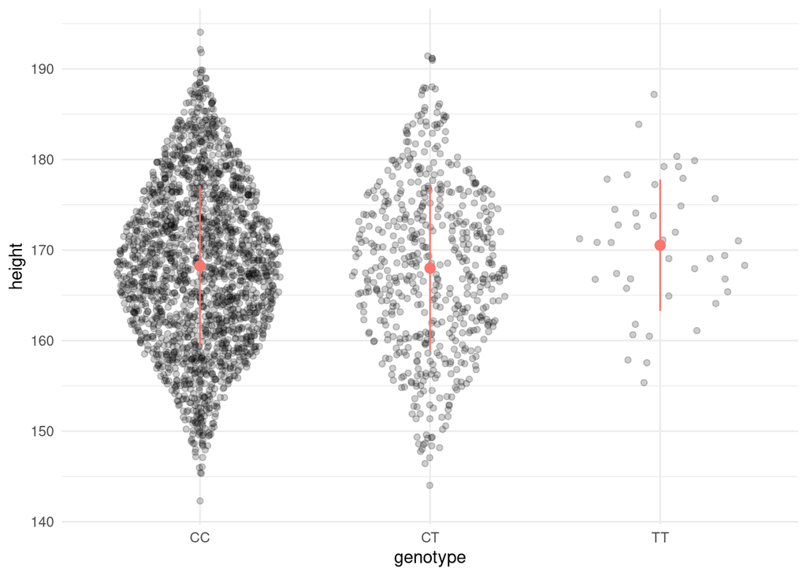

```r
# Your code goes here

# let's make the genotype a factor to clean-up the plot
get_allele <- function(id, df, ref = TRUE) {
  allele = df %>%
    filter(
      variant.id == id
    )
  if (ref) {
    allele = allele$other_allele
  } else {
    allele = allele$effect_allele
  }
  return (
    allele
  )
}

ref_allele = get_allele(542766, gwas1)
alt_allele = get_allele(542766, gwas1, FALSE)

annot_geno = annot_geno %>%
  mutate(
    genotype_fct = factor(
      genotype,
      levels = c(
        0, 1, 2
      ),
      labels = c(
        paste0(ref_allele, ref_allele),
        paste0(ref_allele, alt_allele),
        paste0(alt_allele, alt_allele)
      )
    )
  )

height_by_geno = annot_geno %>%
  group_by(genotype_fct) %>%
  summarize(sd = sd(height, na.rm=T),
  mean = mean(height, na.rm=T))

annot_geno %>%
  ggplot() +
  aes(
    x = genotype_fct,
    y = height
  ) +
  geom_sina(
    alpha = 0.2
  ) +
  geom_pointrange(
    aes(
      x = genotype_fct,
      y = mean,
      ymin = mean - sd,
      ymax = mean + sd,
      colour = "red"
    ),
    data = height_by_geno,
    inherit.aes = FALSE,
    show.legend = FALSE
  ) +
  xlab("genotype") +
  theme_minimal()
```

Given that the CC and CT genotypes are about the same and the TT genotype has a higher associated height, it would probably be best to use a recessive model.